# Estimates of Single Sensor Error Statistics for the MODIS Matchup Database Using Machine Learning

Chirag Kumar and Guillermo Podesta

# Introduction

- NASA: SST = single most important indicator of Climate Change
- Buoys = accurate
  - Not global or repeated
- Sensors aboard satellites
  - Global and repeated
  - Measures Top of Atmosphere Brightness Temperatures
  - Matchups + Atmospheric Correction: TOA BTs –> SST estimate

# Motivation

- High SSTs, measures of atmospheric absorption stop responding proportionally to actual atmospheric absorption
- Attempts to fix this in Atmospheric Correction: multiplying measures of atmospheric absorption by reference SST but problem still persists

```
[1] 40
            x         y
[1,] 115.6643 -18.95999
```

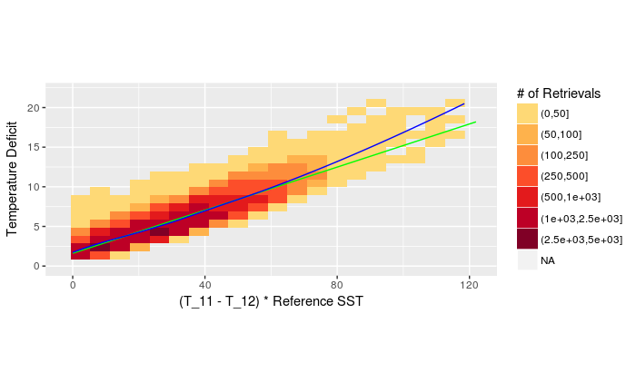

Caption: Figure 1: The green line represents a linear fit to the data while the blue curve is the loess fit.

- Loess = non-parametric, shows the true shape of data
  - locally fits a line to subset of the data then smooths all the lines
- Significant loss of linearity/proportionality at high SSTs (high values of the product)
  - Deviation the loess fit shows from the linear fit
- However, non-linearity at high SSTs doesn’t always lead to an error or residual (satellite SST minus buoy SST)

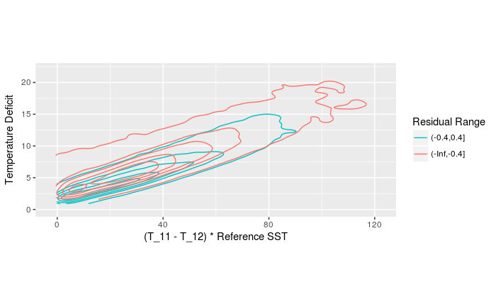

Caption: Figure 2: Contours are drawn around 25, 50, 75, and 99.9% of the data.

- High SSTs = higher chance of having negative residual
  - Not always
- Even at lower SSTs, significant overlap between retrievals of varying residual magnitudes
  - Difficult to separate low residual retrievals from high residual retrievals

# Problem Statement/Question/Proposal

Using Machine Learning to gain intuition for our data, we aim to understand what combinations of geophysical condtions affect residual magnitude specifically in warm SST environments and ultimately precisely and accurately numerically quantify the SST residual.

# Data

- MODIS onboard NASA’s Aqua
- LWIR ($\lambda$ = 10 - 12 $\mu$m)
- Only night-time data to remove sun effects such as diurnal warming and sun glint contamination
- QSST = 0, 1, 2
- Remove any matchup with residual > 0.4
  - Very abnormal, probably pre-flagged and identified
- 1002342 matchups